# Causal Inference

**Boosting**

- A problem with logistic regression for estimating weights is that can be challenging to get a good model fit
- Boosting makes this a lot easier and automatic
- We already talked about AdaBoost and a little about general boosting
- For a reference, in AdaBoost
  - each lazy learner is fitted to the data with weights that depend on the last model’s performance
  - all of the lazy learners are scored depending on their performance
- For general boosting
  - Observations are *not* weighted
  - We use learners (models) like regression or trees that are more complex than lazy learner
  - Similar to AdaBoost, we must choose the number of sequential learner to use, $M$
  - Each learner tries to predict the *error* of the previous model
  - Error: in the literature, the error is the negative gradient of the loss function with respect to the model evaluated at an observation:
    $$-\frac{\partial L(y_i,f(x_i))}{\partial f(x_i)}$$
  - For a continuous outcomes, this is $y_i-f(x_i)$ for continuous outcomes where $f$ is a continuous learner
  - For a binary outcomes, this is $I(y_i=1)-p(x_i)$ where $p$ is a learner like logistic regression model or decision tree
  - For categorical outcomes, this is $I(y_i=\text{Category }k)-p_k(x_i)$ where $p_k$ is models the probability of category $k$
  - Learning rate: to avoid over fitting, we reduce the contribution of each learner by $0<\nu<1$
  - Trees are the most common learner to use for boosting, usually with between 8 and 32 terminal leaves

  **Gradient Tree Boosting Algorithm from ESL**
1. Initialize $f_0(x)=\arg\min_\gamma \sum_{i=1}^n L(y_i,\gamma)$
2. For $m=1$ to $M$:
   1. For $i=1,\dots,n$ compute the error
      $$r_{im}=-\left[\frac{\partial L(y_i,f(x_i))}{\partial f(x_i)}\right]_{f=f_{m-1}}$$
   2. Fit a regression tree to the errors, $r_{im}$ with terminal regions $R_{jm}$ where $j=1,\dots, J_m$
   3. For $j=1,\dots, J_m$ compute
      $$\gamma_{jm}=\arg\min_\gamma \sum_{x_i\in R_{jm}} L(y_i,f_{m-1}(x_i)+\gamma)$$
   4. Update $f_m(x)=f_{m-1}(x)+\nu\sum_{j=1}^{J_m} \gamma_{jm}I(x\in R_{jm})$
3. Output $\hat f(x)=f_M(x)$

**Generalized Boosting for Propensity Scores**

```r
boosted.mod <- ps(treat ~ age + educ + black + hispan + married + nodegree + re74 + re75,
                  data=lalonde,
                  estimand = "ATE",
                  n.trees = 5000,
                  interaction.depth=2,
                  perm.test.iters=0,
                  verbose=FALSE,
                  stop.method = c("es.mean"))
summary(boosted.mod)
```

```
##             n.treat n.ctrl ess.treat ess.ctrl    max.es   mean.es    max.ks
## unw             185    429  185.0000   429.00 1.3085999 0.4432341 0.6404460
## es.mean.ATE     185    429   60.3237   193.34 0.5531452 0.1873810 0.2707165
##             max.ks.p   mean.ks iter
## unw               NA 0.2702451   NA
## es.mean.ATE       NA 0.1168722 2476
```

```r
summary(boosted.mod$gbm.obj,
        n.trees=boosted.mod$desc$es.mean.ATE$n.trees,
        plot=FALSE)
```

```
##               var     rel.inf
## black       black 56.05496593
## re74         re74 16.55677812
## age           age 16.48874057
## re75         re75  4.21479167
## educ         educ  3.16741532
## married   married  2.97674945
## nodegree nodegree  0.44563787
## hispan     hispan  0.09492107
```

```r
lalonde$boosted <- get.weights(boosted.mod)
```

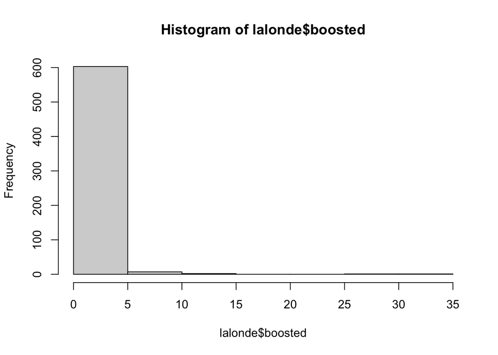

```r
hist(lalonde$boosted)
```

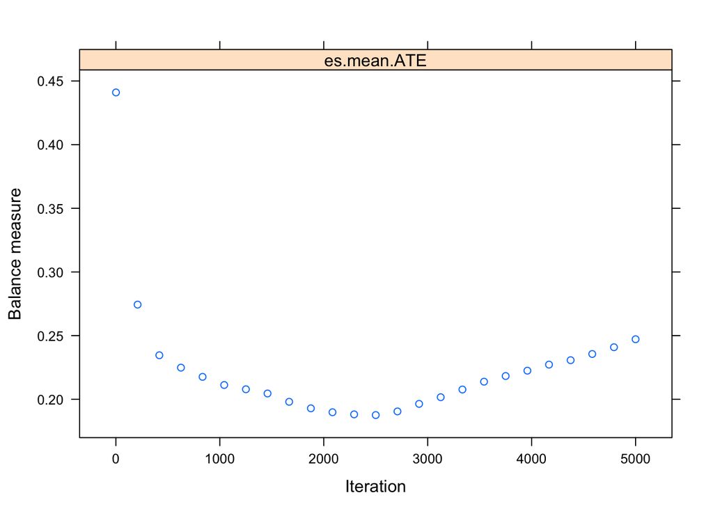

```r
plot(boosted.mod)
```

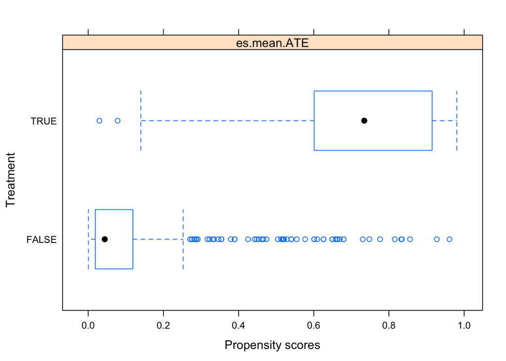

```r
plot(boosted.mod, plots=2)
```

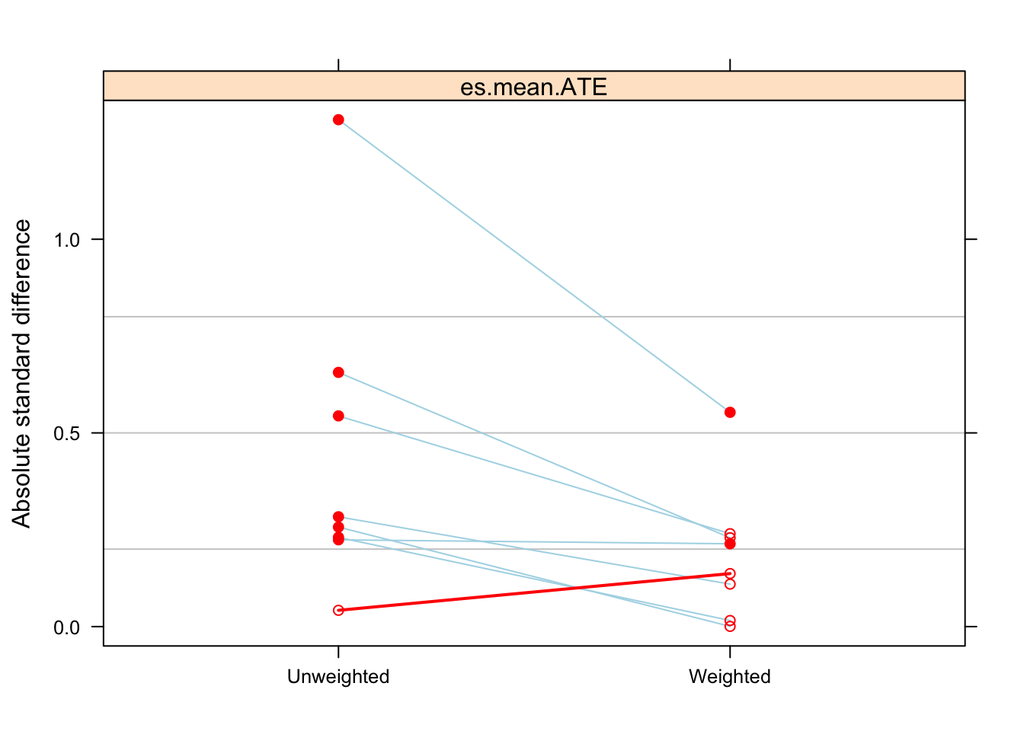

```r
plot(boosted.mod, plots=3)
```

```r
bal.table(boosted.mod)
```

```
## $unw
##             tx.mn    tx.sd    ct.mn    ct.sd std.eff.sz   stat     p    ks
## age        25.816    7.155   28.030   10.787     -0.224 -2.994 0.003 0.158
## educ       10.346    2.011   10.235    2.855      0.042  0.547 0.584 0.111
## black       0.843    0.365    0.203    0.403      1.309 19.371 0.000 0.640
## hispan      0.059    0.237    0.142    0.350     -0.257 -3.413 0.001 0.083
## married     0.189    0.393    0.513    0.500     -0.656 -8.607 0.000 0.324
## nodegree    0.708    0.456    0.597    0.491      0.231  2.716 0.007 0.111
## re74     2095.574 4886.620 5619.237 6788.751     -0.544 -7.254 0.000 0.447
## re75     1532.055 3219.251 2466.484 3291.996     -0.284 -3.282 0.001 0.288
##          ks.pval
## age        0.003
## educ       0.074
## black      0.000
## hispan     0.317
## married    0.000
## nodegree   0.074
## re74       0.000
## re75       0.000
##
## $es.mean.ATE
##             tx.mn    tx.sd    ct.mn    ct.sd std.eff.sz   stat     p    ks
## age        25.366    7.051   27.479   10.057     -0.214 -2.737 0.006 0.135
## educ       10.678    2.035   10.318    2.682      0.137  1.170 0.242 0.090
## black       0.634    0.483    0.364    0.482      0.553  3.087 0.002 0.271
## hispan      0.117    0.323    0.117    0.322      0.001  0.004 0.997 0.000
## married     0.317    0.467    0.430    0.496     -0.229 -1.324 0.186 0.113
## nodegree    0.594    0.492    0.601    0.490     -0.016 -0.095 0.924 0.008
## re74     3033.625 5242.729 4587.500 6420.671     -0.240 -1.877 0.061 0.168
## re75     1784.296 3375.528 2145.837 3190.334     -0.110 -0.940 0.348 0.151
##          ks.pval
## age        0.340
## educ       0.814
## black      0.002
## hispan     1.000
## married    0.555
## nodegree   1.000
## re74       0.133
## re75       0.217
```

## Estimating Average Treatment Effect (ATE)

- Want $E[Y^1] - E[Y^0]$
- Treatment population mean estimate for $t=0,1$:
  $$\widehat\mu_t = \frac{\sum_{i=1}^n I(T_i=t) Y_i w_i(t)}{\sum_{i=1}^n I(T_i=t) w_i(t)}$$
- Estimate $E[Y^1] - E[Y^0]$ as
  $$\widehat{\text{ATE}} = \widehat\mu_1-\widehat\mu_0$$
- We can use a weighted *t-test* to evaluate $\widehat{\text{ATE}}$
- McCaffery et all suggests using `svyglm` which achieves the same goal

```r
library(survey)
design <- svydesign(ids=~1, weights=~boosted, data=lalonde)
glm1 <- svyglm(re78 ~ treat, design=design)
summary(glm1)
```

```
##
## Call:
## svyglm(formula = re78 ~ treat, design = design)
##
## Survey design:
## svydesign(ids = ~1, weights = ~boosted, data = lalonde)
##
## Coefficients:
##             Estimate Std. Error t value Pr(>|t|)
## (Intercept)   6646.4      388.3  17.116   <2e-16 ***
## treatTRUE     -719.5      865.5  -0.831    0.406
## ---
## Signif. codes:  0 '***' 0.001 '**' 0.01 '*' 0.05 '.' 0.1 ' ' 1
##
## (Dispersion parameter for gaussian family taken to be 49534038)
##
## Number of Fisher Scoring iterations: 2
```

```r
summary(lm(re78 ~ treat + age + educ+  black + hispan + married + nodegree + re74 + re75, data=lalonde))
```

```
##
## Call:
## lm(formula = re78 ~ treat + age + educ + black + hispan + married +
##     nodegree + re74 + re75, data = lalonde)
##
## Residuals:
##    Min     1Q Median     3Q    Max
## -13595  -4894  -1662   3929  54570
##
## Coefficients:
##               Estimate Std. Error t value Pr(>|t|)
## (Intercept)  6.651e+01  2.437e+03   0.027   0.9782
## treatTRUE    1.548e+03  7.813e+02   1.982   0.0480 *
## age          1.298e+01  3.249e+01   0.399   0.6897
## educ         4.039e+02  1.589e+02   2.542   0.0113 *
## black       -1.241e+03  7.688e+02  -1.614   0.1071
## hispan       4.989e+02  9.419e+02   0.530   0.5966
## married      4.066e+02  6.955e+02   0.585   0.5590
## nodegree     2.598e+02  8.474e+02   0.307   0.7593
## re74         2.964e-01  5.827e-02   5.086 4.89e-07 ***
## re75         2.315e-01  1.046e-01   2.213   0.0273 *
## ---
## Signif. codes:  0 '***' 0.001 '**' 0.01 '*' 0.05 '.' 0.1 ' ' 1
##
## Residual standard error: 6948 on 604 degrees of freedom
## Multiple R-squared:  0.1478, Adjusted R-squared:  0.1351
## F-statistic: 11.64 on 9 and 604 DF,  p-value: < 2.2e-16
```

- interpretation: causal vs statistical
- Limitation: Umeasured confounding

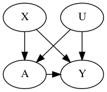

## Writing tips

- Intro paragraph:
  - Give the big picture in one sentence. What is the general application field?
  - What is the problem you are attempting to answer?
  - How will you answer it?
  - In one sentence, what did you find?
- Give the baseline characteristics of the data after cleaning
  - How many observations with salient brake down
  - A table is a very efficient way to summarize data:

|  | Total (n) | Treatment (n1) | Control (n2) | p-value |
| --- | --- | --- | --- | --- |
| Covariate 1 | mean (sd) | mean (sd) | mean (sd) | <0.001 |
| Covariate 2 | % | % | % | 0.34 |
| Covariate 3 | median (q1, q3) | median (q1, q3) | median (q1, q3) | 0.02 |

- Present you most important model (or models)
  - Clearly interpret the parameter of interest and its connection to the larger question that is being asked
  - A lot of this material is technical. You’re job is to understand the larger statistical picture and communicate it in an easy to understand way to someone who does not have any background in statistics an who probably does not do math regularly
- Example: how would you describe IPW to a client?
  1. Why do we use IPW in the first place?
  2. What does IPW do?
  3. How does IPW attempt to allow a causal interpretation for ATE?
- Conclusion:
  - Restate what you attempted to answer
  - State any potential limitation
  - Reiterate findings
- Don’t
  - try to explain d-separation or Bayesian networks
  - think of a statistician as your audience
- Do
  - rely on intuition about causation
  - use your understanding of causal modeling to answer the question